# Laptop Price Model Building in ML

- Name : SAGNIK SAMANTA
- Internship ID : UMIP26929
- Internship : Data Analyst Intern at UnifiedMentor
- Project : Laptop Price Analysis

### Introduction

Laptots are lightweight and Portable,making them easy to carry and use them anywhere,anytime.Laptops enable users to work,study and communicate from anywhere,leading to increased Productivity and efficiency.In today's rapidly evolving technological environment laptops are essential tools for individuals and businesses alike.Accurate prediction of laptop prices helps retailers develop effective pricing strategies and enables consumers to plan their budgets and select the most suitable laptops.

### Column Description :

Provided Laptop dataset contains 1275 observations on 23 feature variables.The descriptions of the feature variables are stated below :

- Company : Laptop Manufacturer.
- Product : Brand and Model.
- TypeName : Laptop Type (Notebook, Ultrabook, Gaming, ...etc).
- Inches : Screen Size.
- Ram : Total amount of RAM in laptop (GBs).
- OS : Operating System installed.
- Weight : Laptop Weight in kilograms.
- Price_euros : Price of Laptop in Euros. (Target)
- Screen : screen definition (Standard, Full HD, 4K Ultra HD, Quad HD+).
- ScreenW : screen width (pixels).
- ScreenH : screen height (pixels).
- Touchscreen : whether or not the laptop has a touchscreen.
- IPSpanel: whether or not the laptop has an IPSpanel.
- RetinaDisplay : whether or not the laptop has retina display.
- CPU_company
- CPU_freq: frequency of laptop CPU (Hz).
- CPU_model
- PrimaryStorage : primary storage space (GB).
- PrimaryStorageType : primary storage type (HDD, SSD, Flash Storage, Hybrid).
- SecondaryStorage : secondary storage space if any (GB).
- SecondaryStorageType : secondary storage type (HDD, SSD, Hybrid, None).
- GPU_company
- GPU_model

```python
## Import necessary libraries
import numpy as np
import pandas as pd
import matplotlib.pyplot as plt
import seaborn as sns
from sklearn.model_selection import train_test_split
from sklearn.linear_model import LinearRegression
from sklearn.preprocessing import LabelEncoder
from sklearn.preprocessing import StandardScaler
from sklearn.ensemble import RandomForestRegressor
from sklearn.metrics import r2_score,mean_squared_error,mean_absolute_error
```

```python
## Load the Dataset
df=pd.read_csv("C:/Users/SAGNIK SAMANTA/OneDrive/Desktop/Datasets/laptop_prices.csv")
df.head()
```

|  | Company | Product | TypeName | Inches | Ram | OS | Weight | Price_euros | Screen | ScreenW | ... | RetinaDisplay | CPU_company | CPU_freq | CPU_model | PrimaryStorage | SecondaryStorage | PrimaryStorageType | SecondaryStorageType | GPU_company | GPU_model |
| --- | --- | --- | --- | --- | --- | --- | --- | --- | --- | --- | --- | --- | --- | --- | --- | --- | --- | --- | --- | --- | --- |
| 0 | Apple | MacBook Pro | Ultrabook | 13.3 | 8 | macOS | 1.37 | 1339.69 | Standard | 2560 | ... | Yes | Intel | 2.3 | Core i5 | 128 | 0 | SSD | No | Intel | Iris Plus Graphics 640 |
| 1 | Apple | Macbook Air | Ultrabook | 13.3 | 8 | macOS | 1.34 | 898.94 | Standard | 1440 | ... | No | Intel | 1.8 | Core i5 | 128 | 0 | Flash Storage | No | Intel | HD Graphics 6000 |
| 2 | HP | 250 G6 | Notebook | 15.6 | 8 | No OS | 1.86 | 575.00 | Full HD | 1920 | ... | No | Intel | 2.5 | Core i5 7200U | 256 | 0 | SSD | No | Intel | HD Graphics 620 |
| 3 | Apple | MacBook Pro | Ultrabook | 15.4 | 16 | macOS | 1.83 | 2537.45 | Standard | 2880 | ... | Yes | Intel | 2.7 | Core i7 | 512 | 0 | SSD | No | AMD | Radeon Pro 455 |
| 4 | Apple | MacBook Pro | Ultrabook | 13.3 | 8 | macOS | 1.37 | 1803.60 | Standard | 2560 | ... | Yes | Intel | 3.1 | Core i5 | 256 | 0 | SSD | No | Intel | Iris Plus Graphics 650 |

5 rows × 23 columns

```python
df.shape
```

```
(1275, 23)
```

```python
df.columns
```

```
Index(['Company', 'Product', 'TypeName', 'Inches', 'Ram', 'OS', 'Weight',
       'Price_euros', 'Screen', 'ScreenW', 'ScreenH', 'Touchscreen',
       'IPSpanel', 'RetinaDisplay', 'CPU_company', 'CPU_freq', 'CPU_model',
       'PrimaryStorage', 'SecondaryStorage', 'PrimaryStorageType',
       'SecondaryStorageType', 'GPU_company', 'GPU_model'],
      dtype='object')
```

```python
df.info()
```

```
<class 'pandas.core.frame.DataFrame'>
RangeIndex: 1275 entries, 0 to 1274
Data columns (total 23 columns):
 #   Column                Non-Null Count  Dtype
---  ------                --------------  -----
 0   Company               1275 non-null   object
 1   Product               1275 non-null   object
 2   TypeName              1275 non-null   object
 3   Inches                1275 non-null   float64
 4   Ram                   1275 non-null   int64
 5   OS                    1275 non-null   object
 6   Weight                1275 non-null   float64
 7   Price_euros           1275 non-null   float64
 8   Screen                1275 non-null   object
 9   ScreenW               1275 non-null   int64
 10  ScreenH               1275 non-null   int64
 11  Touchscreen           1275 non-null   object
 12  IPSpanel              1275 non-null   object
 13  RetinaDisplay         1275 non-null   object
 14  CPU_company           1275 non-null   object
 15  CPU_freq              1275 non-null   float64
 16  CPU_model             1275 non-null   object
 17  PrimaryStorage        1275 non-null   int64
 18  SecondaryStorage      1275 non-null   int64
 19  PrimaryStorageType    1275 non-null   object
 20  SecondaryStorageType  1275 non-null   object
 21  GPU_company           1275 non-null   object
 22  GPU_model             1275 non-null   object
dtypes: float64(4), int64(5), object(14)
memory usage: 229.2+ KB
```

```python
## Checking for missing values
print(df.isnull().sum())
```

```
Company                 0
Product                 0
TypeName                0
Inches                  0
Ram                     0
OS                      0
Weight                  0
Price_euros             0
Screen                  0
ScreenW                 0
ScreenH                 0
Touchscreen             0
IPSpanel                0
RetinaDisplay           0
CPU_company             0
CPU_freq                0
CPU_model               0
PrimaryStorage          0
SecondaryStorage        0
PrimaryStorageType      0
SecondaryStorageType    0
GPU_company             0
GPU_model               0
dtype: int64
```

```python
## Drop rows with missing values
df.dropna(inplace=True)
```

```python
df.duplicated().sum()
```

```
0
```

```python
## Separating Categorical and Numerical values
catvars = df.select_dtypes(include=['object']).columns
numvars = df.select_dtypes(include = ['int32','int64','float32','float64']).columns

catvars,numvars
```

```
(Index(['Company', 'Product', 'TypeName', 'OS', 'Screen', 'Touchscreen',
        'IPSpanel', 'RetinaDisplay', 'CPU_company', 'CPU_model',
        'PrimaryStorageType', 'SecondaryStorageType', 'GPU_company',
        'GPU_model'],
       dtype='object'),
 Index(['Inches', 'Ram', 'Weight', 'Price_euros', 'ScreenW', 'ScreenH',
        'CPU_freq', 'PrimaryStorage', 'SecondaryStorage'],
       dtype='object'))
```

```python
df["Company"].value_counts()
```

```
Company
Dell         291
Lenovo       289
HP           268
Asus         152
Acer         101
MSI           54
Toshiba       48
Apple         21
Samsung        9
Razer          7
Mediacom       7
Microsoft      6
Xiaomi         4
Vero           4
Chuwi          3
Google         3
Fujitsu        3
LG             3
Huawei         2
Name: count, dtype: int64
```

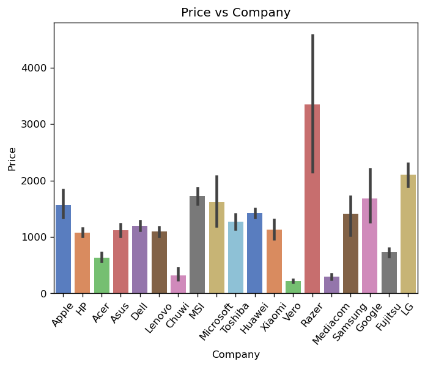

```python
plt.figure(dpi=120)
sns.barplot(x="Company",y="Price_euros",palette="muted",data=df)
plt.xlabel("Company")
plt.ylabel("Price")
plt.xticks(rotation=50)
plt.title("Price vs Company")
plt.show()
```

```python
df["Product"].value_counts()
```

```
Product
XPS 13                                 30
Inspiron 3567                          25
250 G6                                 21
Vostro 3568                            19
Legion Y520-15IKBN                     19
                                       ..
VivoBook E201NA                         1
Ideapad 520-15IKBR                      1
Thinkpad X260                           1
Rog G752VL-UH71T                        1
X553SA-XX031T (N3050/4GB/500GB/W10)     1
Name: count, Length: 618, dtype: int64
```

[figure not shown]

```python
plt.figure(figsize=(10,10))
sns.barplot(x="Product",y="Price_euros",palette="muted",data=df)
plt.xlabel("Product")
plt.ylabel("Price")
plt.xticks(rotation=50)
plt.title("Price vs Product")
plt.show()
```

```python
df["TypeName"].value_counts()
```

```
TypeName
Notebook              707
Gaming                205
Ultrabook             194
2 in 1 Convertible    117
Workstation            29
Netbook                23
Name: count, dtype: int64
```

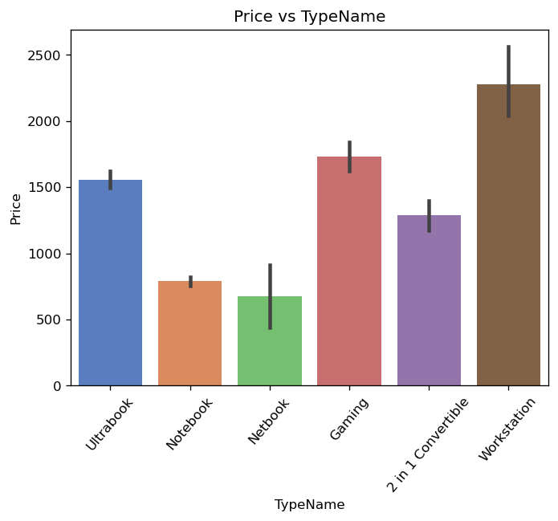

```python
plt.figure(dpi=120)
sns.barplot(x="TypeName",y="Price_euros",palette="muted",data=df)
plt.xlabel("TypeName")
plt.ylabel("Price")
plt.xticks(rotation=50)
plt.title("Price vs TypeName")
plt.show()
```

```python
df["OS"].value_counts()
```

```
OS
Windows 10      1048
No OS             66
Linux             58
Windows 7         45
Chrome OS         27
macOS             13
Mac OS X           8
Windows 10 S       8
Android            2
Name: count, dtype: int64
```

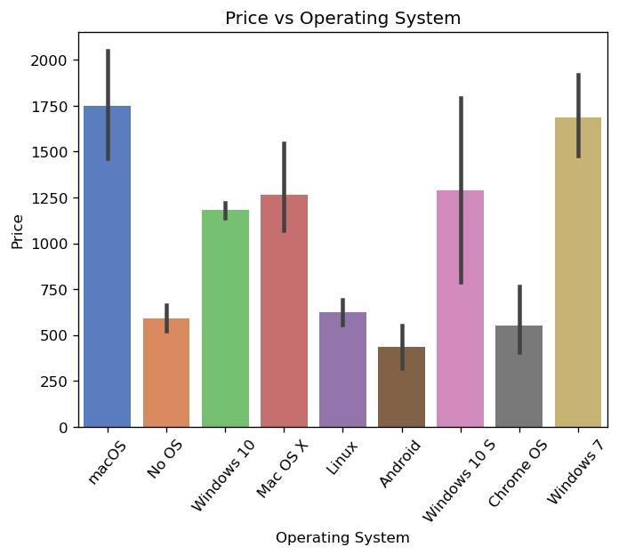

```python
plt.figure(dpi=120)
sns.barplot(x="OS",y="Price_euros",palette="muted",data=df)
plt.xlabel("Operating System")
plt.ylabel("Price")
plt.xticks(rotation=50)
plt.title("Price vs Operating System")
plt.show()
```

```python
df["Touchscreen"].value_counts()
```

```
Touchscreen
No     1087
Yes     188
Name: count, dtype: int64
```

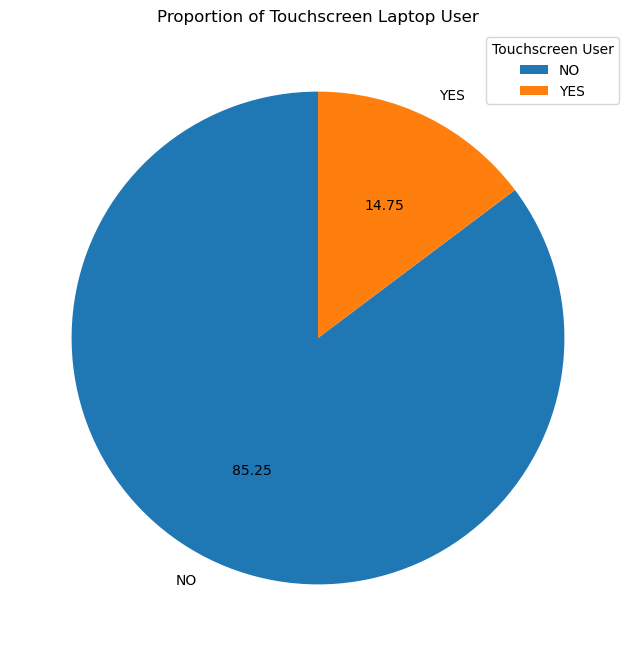

```python
plt.figure(figsize=(10,8))
plt.pie(df["Touchscreen"].value_counts(),labels=["NO","YES"],autopct="%0.2f",startangle=90,shadow=False)
plt.title("Proportion of Touchscreen Laptop User")
plt.legend(title="Touchscreen User",loc=1)
plt.show()
```

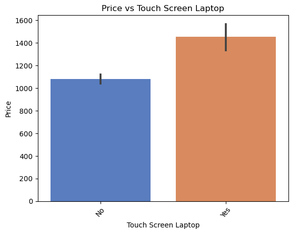

```python
plt.figure(dpi=100)
sns.barplot(x="Touchscreen",y="Price_euros",palette="muted",data=df)
plt.xlabel("Touch Screen Laptop")
plt.ylabel("Price")
plt.xticks(rotation=50)
plt.title("Price vs Touch Screen Laptop")
plt.show()
```

```python
df["Screen"].value_counts()
```

```
Screen
Full HD        835
Standard       369
4K Ultra HD     43
Quad HD+        28
Name: count, dtype: int64
```

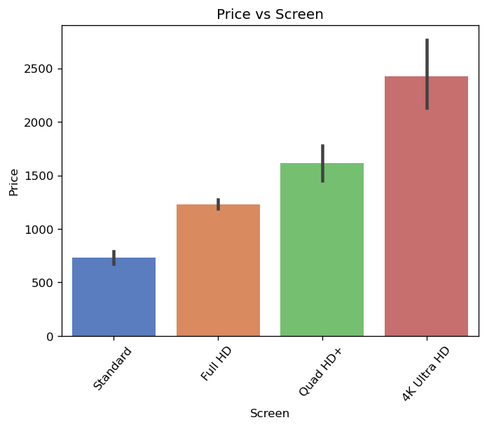

```python
plt.figure(dpi=120)
sns.barplot(x="Screen",y="Price_euros",palette="muted",data=df)
plt.xlabel("Screen")
plt.ylabel("Price")
plt.xticks(rotation=50)
plt.title("Price vs Screen")
plt.show()
```

```python
df["IPSpanel"].value_counts()
```

```
IPSpanel
No     918
Yes    357
Name: count, dtype: int64
```

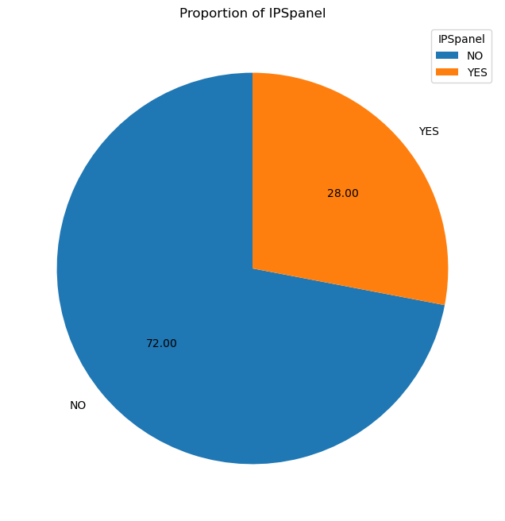

```python
plt.figure(figsize=(10,8))
plt.pie(df["IPSpanel"].value_counts(),labels=["NO","YES"],autopct="%0.2f",startangle=90,shadow=False)
plt.title("Proportion of IPSpanel")
plt.legend(title="IPSpanel",loc=1)
plt.show()
```

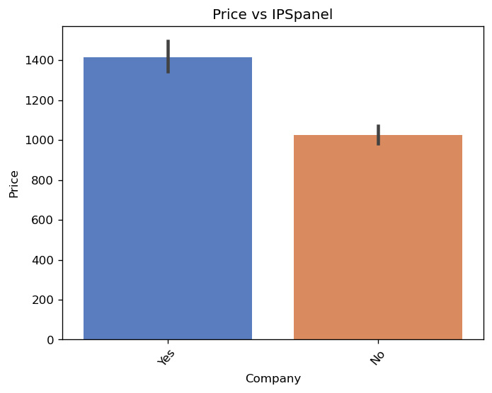

```python
plt.figure(dpi=120)
sns.barplot(x="IPSpanel",y="Price_euros",palette="muted",data=df)
plt.xlabel("Company")
plt.ylabel("Price")
plt.xticks(rotation=50)
plt.title("Price vs IPSpanel")
plt.show()
```

```python
df["RetinaDisplay"].value_counts()
```

```
RetinaDisplay
No     1258
Yes      17
Name: count, dtype: int64
```

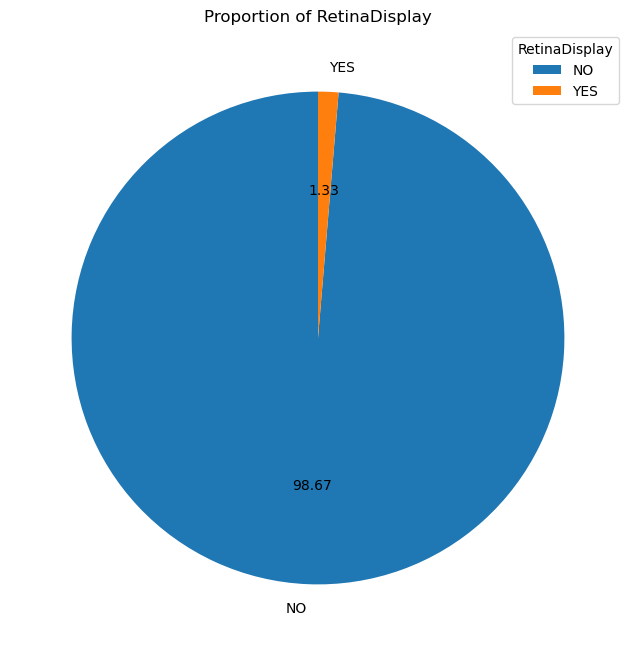

```python
plt.figure(figsize=(10,8))
plt.pie(df["RetinaDisplay"].value_counts(),labels=["NO","YES"],autopct="%0.2f",startangle=90,shadow=False)
plt.title("Proportion of RetinaDisplay")
plt.legend(title="RetinaDisplay",loc=1)
plt.show()
```

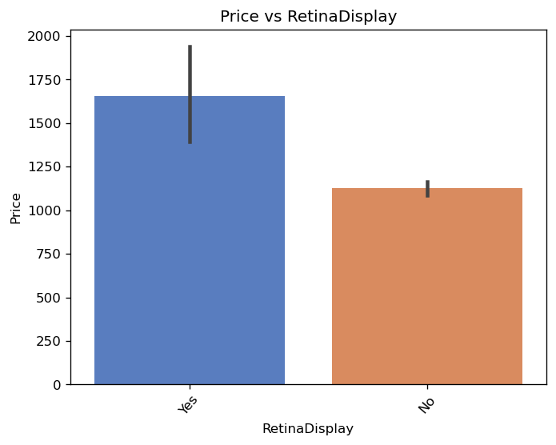

```python
plt.figure(dpi=120)
sns.barplot(x="RetinaDisplay",y="Price_euros",palette="muted",data=df)
plt.xlabel("RetinaDisplay")
plt.ylabel("Price")
plt.xticks(rotation=50)
plt.title("Price vs RetinaDisplay")
plt.show()
```

```python
df["CPU_model"].value_counts()
```

```
CPU_model
Core i5 7200U       193
Core i7 7700HQ      147
Core i7 7500U       133
Core i3 6006U        81
Core i7 8550U        73
                   ...
Core M m3             1
E-Series E2-9000      1
Core M M3-6Y30        1
A6-Series 7310        1
A9-Series 9410        1
Name: count, Length: 93, dtype: int64
```

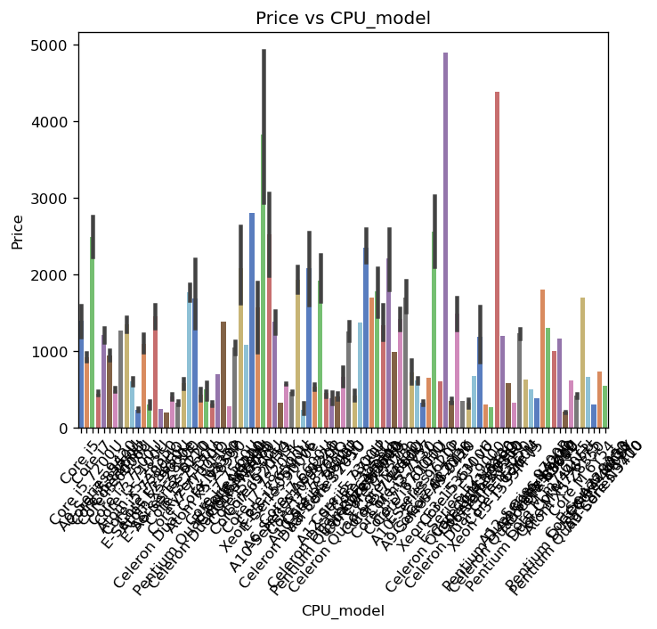

```python
plt.figure(dpi=120)
sns.barplot(x="CPU_model",y="Price_euros",palette="muted",data=df)
plt.xlabel("CPU_model")
plt.ylabel("Price")
plt.xticks(rotation=50)
plt.title("Price vs CPU_model")
plt.show()
```

```python
df["GPU_model"].value_counts()
```

```
GPU_model
HD Graphics 620     279
HD Graphics 520     181
UHD Graphics 620     68
GeForce GTX 1050     66
GeForce GTX 1060     48
                   ...
Radeon R5 520         1
Radeon R7             1
HD Graphics 540       1
Radeon 540            1
Mali T860 MP4         1
Name: count, Length: 110, dtype: int64
```

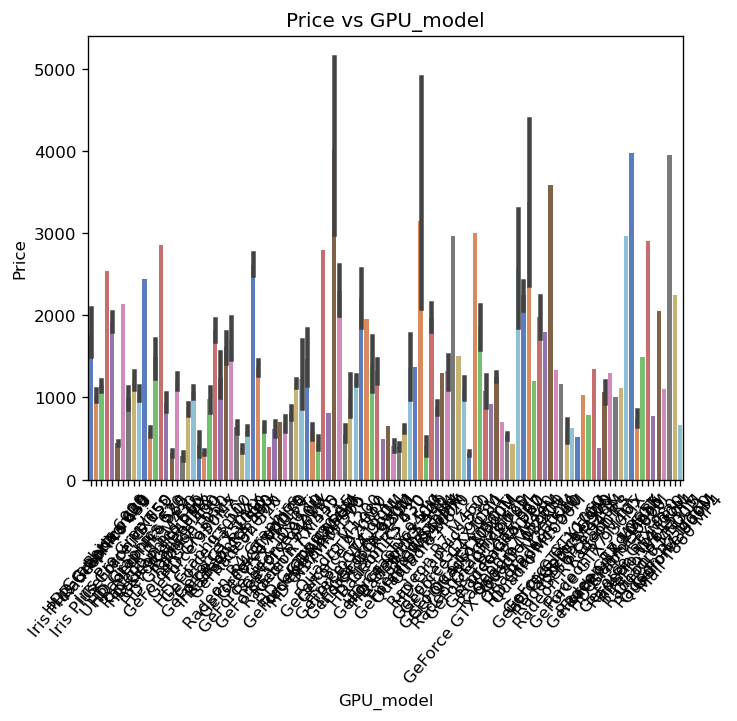

```python
plt.figure(dpi=120)
sns.barplot(x="GPU_model",y="Price_euros",palette="muted",data=df)
plt.xlabel("GPU_model")
plt.ylabel("Price")
plt.xticks(rotation=50)
plt.title("Price vs GPU_model")
plt.show()
```

```python
df["PrimaryStorageType"].value_counts()
```

```
PrimaryStorageType
SSD              837
HDD              359
Flash Storage     71
Hybrid             8
Name: count, dtype: int64
```

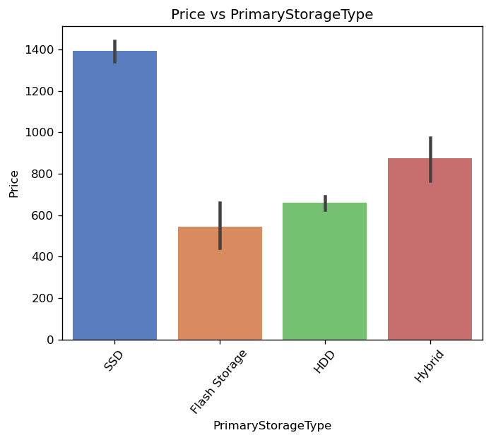

```python
plt.figure(dpi=120)
sns.barplot(x="PrimaryStorageType",y="Price_euros",palette="muted",data=df)
plt.xlabel("PrimaryStorageType")
plt.ylabel("Price")
plt.xticks(rotation=50)
plt.title("Price vs PrimaryStorageType")
plt.show()
```

```python
df["SecondaryStorageType"].value_counts()
```

```
SecondaryStorageType
No        1067
HDD        202
SSD          4
Hybrid       2
Name: count, dtype: int64
```

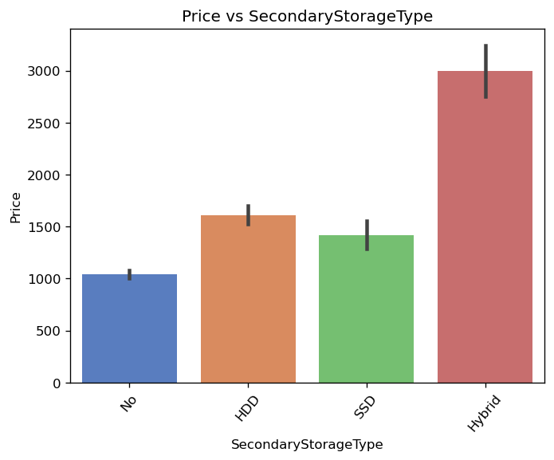

```python
plt.figure(dpi=120)
sns.barplot(x="SecondaryStorageType",y="Price_euros",palette="muted",data=df)
plt.xlabel("SecondaryStorageType")
plt.ylabel("Price")
plt.xticks(rotation=50)
plt.title("Price vs SecondaryStorageType")
plt.show()
```

```python
df["CPU_company"].value_counts()
```

```
CPU_company
Intel      1214
AMD          60
Samsung       1
Name: count, dtype: int64
```

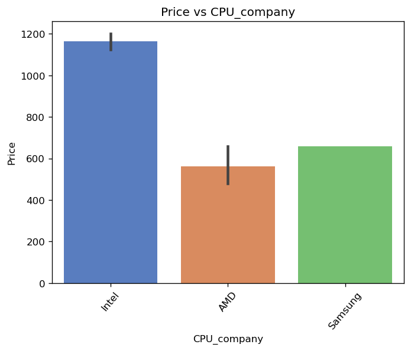

```python
plt.figure(dpi=120)
sns.barplot(x="CPU_company",y="Price_euros",palette="muted",data=df)
plt.xlabel("CPU_company")
plt.ylabel("Price")
plt.xticks(rotation=50)
plt.title("Price vs CPU_company")
plt.show()
```

```python
df["GPU_company"].value_counts()
```

```
GPU_company
Intel     704
Nvidia    396
AMD       174
ARM         1
Name: count, dtype: int64
```

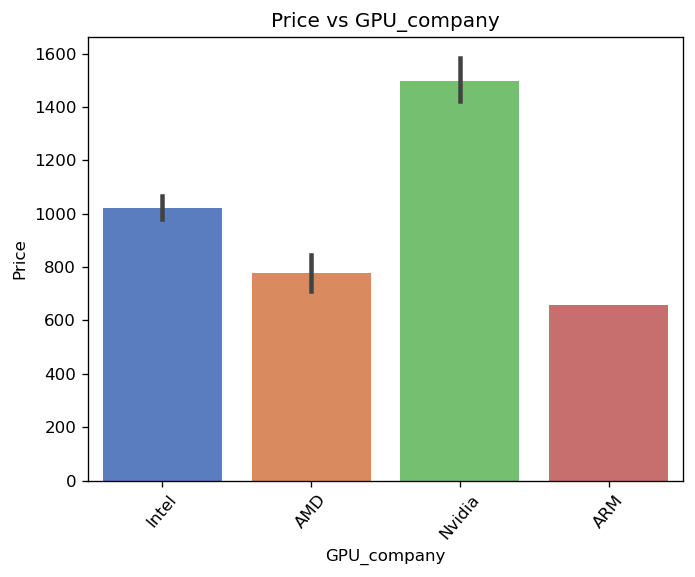

```python
plt.figure(dpi=120)
sns.barplot(x="GPU_company",y="Price_euros",palette="muted",data=df)
plt.xlabel("GPU_company")
plt.ylabel("Price")
plt.xticks(rotation=50)
plt.title("Price vs GPU_company")
plt.show()
```

### Visualizing Parameters

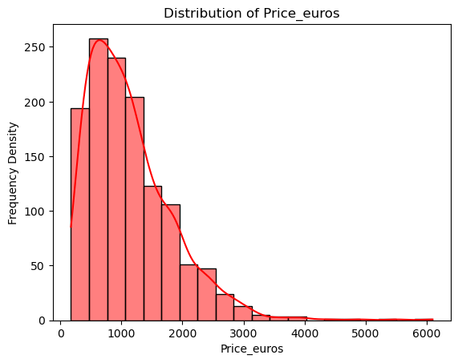

```python
plt.figure(dpi=100)
sns.histplot(x="Price_euros",kde=True,color="r",bins=20,data=df)
plt.xlabel("Price_euros")
plt.ylabel("Frequency Density")
plt.title("Distribution of Price_euros")
plt.show()
```

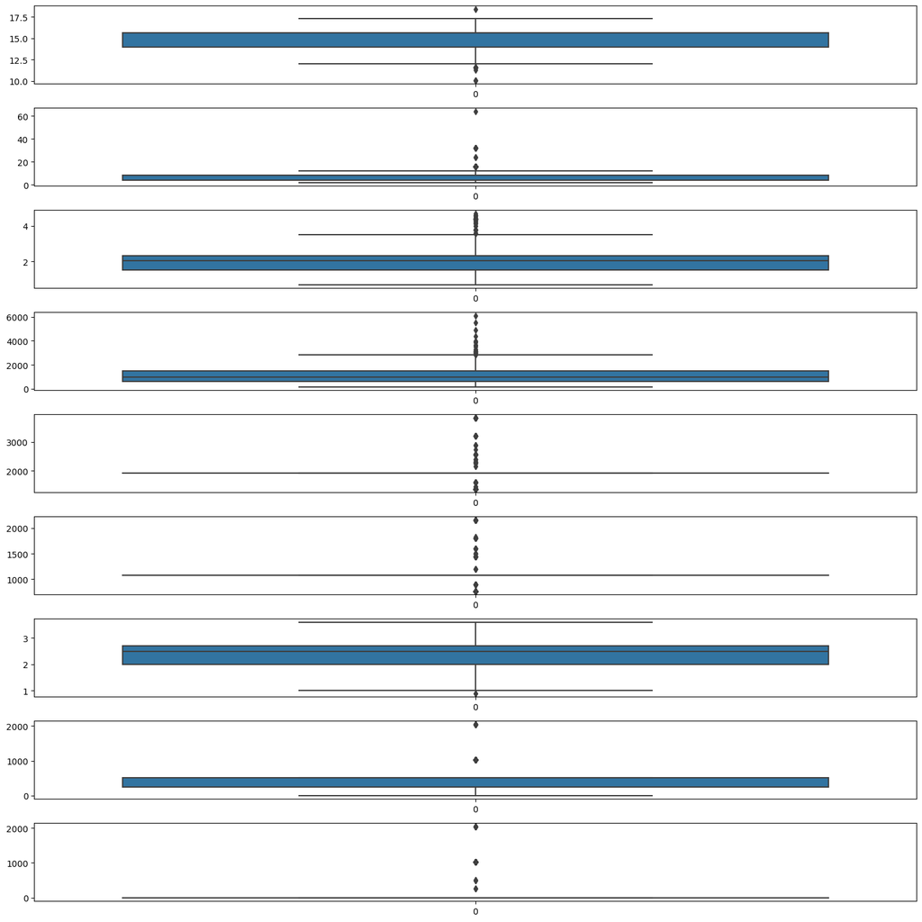

```python
# Outlier Analysis
fig, axs = plt.subplots(9, figsize = (15,15))
plt1 = sns.boxplot(df['Inches'], ax = axs[0])
plt2 = sns.boxplot(df['Ram'], ax = axs[1])
plt3 = sns.boxplot(df['Weight'], ax = axs[2])
plt4 = sns.boxplot(df['Price_euros'], ax = axs[3])
plt5 = sns.boxplot(df['ScreenW'], ax = axs[4])
plt6 = sns.boxplot(df['ScreenH'], ax = axs[5])
plt7 = sns.boxplot(df['CPU_freq'], ax = axs[6])
plt8 = sns.boxplot(df['PrimaryStorage'], ax = axs[7])
plt9 = sns.boxplot(df['SecondaryStorage'], ax = axs[8])
plt.tight_layout()
```

#### From the above Price distribution graph we can see that Laptop with the lower price has a high demand compared to branded one.

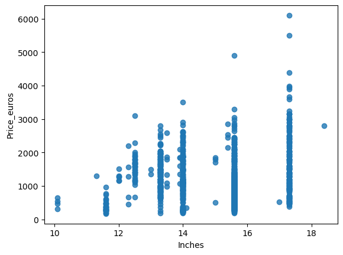

```python
## Inches vs Price_euros
sns.regplot(x="Inches",y="Price_euros",scatter=True,fit_reg=False,data=df)
```

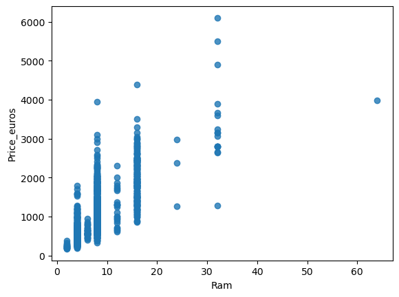

```python
## Ram vs Price_euros
sns.regplot(x="Ram",y="Price_euros",scatter=True,fit_reg=False,data=df)
```

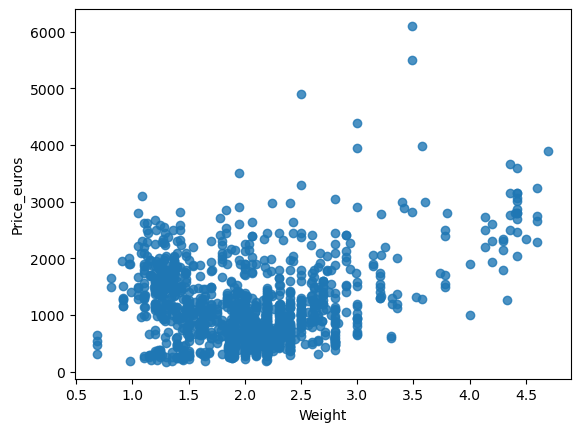

```python
## Weight vs Price_euros
sns.regplot(x="Weight",y="Price_euros",scatter=True,fit_reg=False,data=df)
```

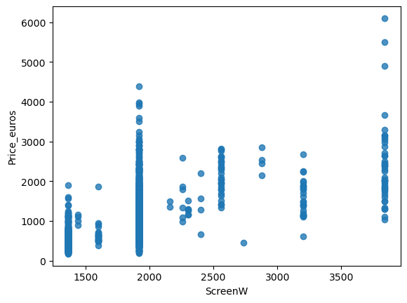

```python
## ScreenW vs Price_euros
sns.regplot(x="ScreenW",y="Price_euros",scatter=True,fit_reg=False,data=df)
```

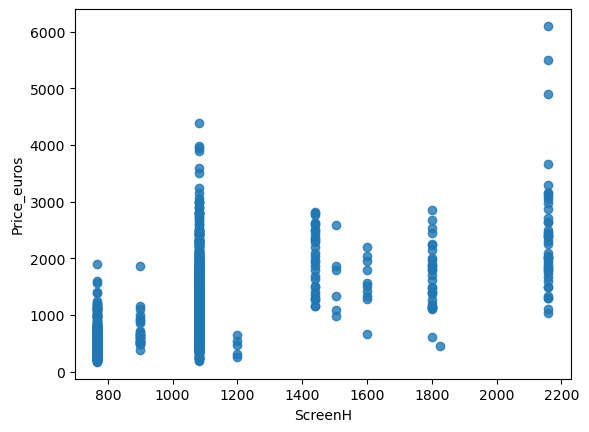

```python
## ScreenH vs Price_euros
sns.regplot(x="ScreenH",y="Price_euros",scatter=True,fit_reg=False,data=df)
```

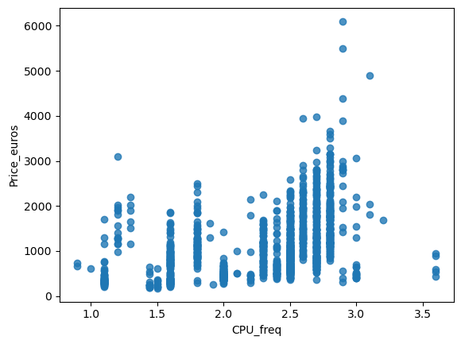

```python
## CPU_freq vs Price_euros
sns.regplot(x="CPU_freq",y="Price_euros",scatter=True,fit_reg=False,data=df)
```

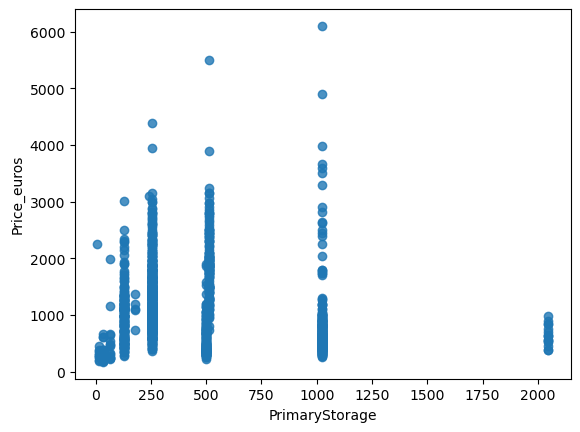

```python
## PrimaryStorage vs Price_euros
sns.regplot(x="PrimaryStorage",y="Price_euros",scatter=True,fit_reg=False,data=df)
```

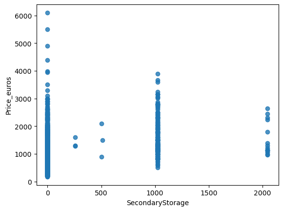

```python
## SecondaryStorage vs Price_euros
sns.regplot(x="SecondaryStorage",y="Price_euros",scatter=True,fit_reg=False,data=df)
```

Before proceeding to analysis we need to convert categorical variables into numerical variables using Label Encoding or One-Hot Encoding.

```python
## Convert categorical variables to numerical variables
le = LabelEncoder()
df['Company'] = le.fit_transform(df['Company'])
df['Product'] = le.fit_transform(df['Product'])
df['TypeName'] = le.fit_transform(df['TypeName'])
df['OS'] = le.fit_transform(df['OS'])
df['Screen'] = le.fit_transform(df['Screen'])
df['RetinaDisplay'] = le.fit_transform(df['RetinaDisplay'])
df['CPU_company'] = le.fit_transform(df['CPU_company'])
df['GPU_company'] = le.fit_transform(df['GPU_company'])
df['PrimaryStorageType'] = le.fit_transform(df['PrimaryStorageType'])
df['SecondaryStorageType'] = le.fit_transform(df['SecondaryStorageType'])
df['GPU_model'] = le.fit_transform(df['GPU_model'])
df['CPU_model'] = le.fit_transform(df['CPU_model'])
df['Touchscreen'] = le.fit_transform(df['Touchscreen'])
df['IPSpanel'] = le.fit_transform(df['IPSpanel'])
```

### Train Test split

We need to select our Feature Variables(Independent Variables) and Target variable(Response Variable).Thereafter split the dataset into training and testing dataset to evaluate the model's performance.

```python
X=df.drop("Price_euros",axis=1)
y=df["Price_euros"]
```

```python
## Split the data into training and testing sets
X_train, X_test, y_train, y_test = train_test_split(X, y, test_size=0.2, random_state=42)
```

```python
## Scale the data using StandardScaler
scaler = StandardScaler()
X_train_scaled = scaler.fit_transform(X_train)
X_test_scaled = scaler.transform(X_test)
```

### Multiple Linear Regression Model

```python
## Create a multiple linear regression model
ln_reg = LinearRegression()

## Train the model
ln_reg.fit(X_train_scaled, y_train)
```

```
LinearRegression()
```

```python
## Make predictions on test dataset
y_pred = ln_reg.predict(X_test_scaled)
```

```python
## Evaluate the Model Performance
mae = mean_absolute_error(y_test, y_pred)
mse = mean_squared_error(y_test, y_pred)
rmse = np.sqrt(mse)
r2 = r2_score(y_test, y_pred)
print(f"Mean Absolute Error :{mae:.2f}")
print(f"Root Mean Squared Error: {rmse:.2f}")
print(f"R-squared: {r2:.2f}")
```

```
Mean Absolute Error :257.81
Root Mean Squared Error: 358.02
R-squared: 0.74
```

```python
## Actual Price and the Predicted Price
reg_model_diff = pd.DataFrame({'Actual Laptop Price': y_test, 'Predicted Laptop Price': y_pred})
reg_model_diff
```

|  | Actual Laptop Price | Predicted Laptop Price |
| --- | --- | --- |
| 1179 | 650.0 | 605.186930 |
| 342 | 716.0 | 932.670068 |
| 649 | 1584.0 | 1530.857782 |
| 772 | 1020.0 | 939.700915 |
| 803 | 1749.0 | 1831.412106 |
| ... | ... | ... |
| 701 | 399.0 | 612.305397 |
| 1105 | 1413.1 | 1307.588596 |
| 424 | 2799.0 | 2266.791672 |
| 944 | 1299.0 | 1031.307508 |
| 65 | 1983.0 | 1793.509666 |

255 rows × 2 columns

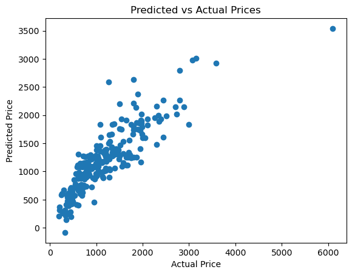

```python
## Plot the Predicted vs Actual Prices
plt.scatter(y_test, y_pred)
plt.xlabel("Actual Price")
plt.ylabel("Predicted Price")
plt.title("Predicted vs Actual Prices")
plt.show()
```

### Regression diagnostics- Residual plot analysis

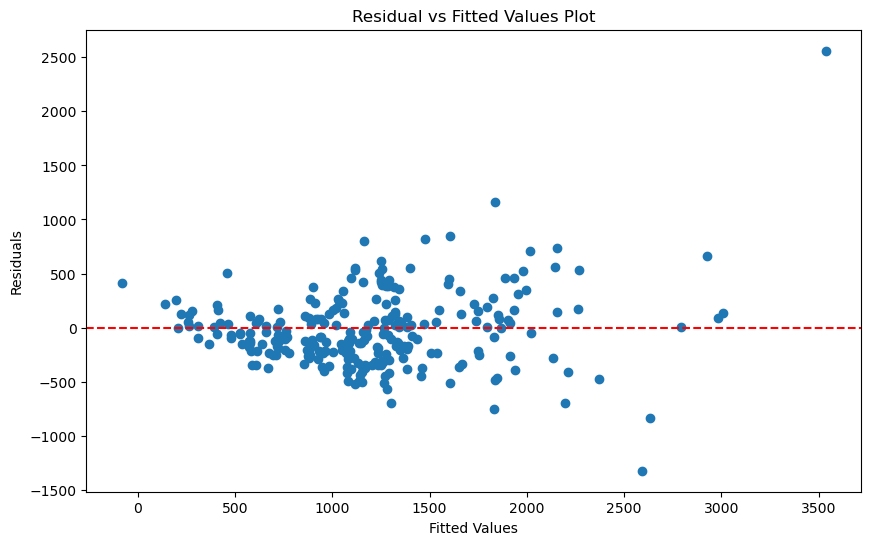

```python
residuals = y_test-y_pred

# Create a residual vs fitted values plot
plt.figure(figsize=(10, 6))
plt.scatter(y_pred, residuals)
plt.xlabel('Fitted Values')
plt.ylabel('Residuals')
plt.title('Residual vs Fitted Values Plot')
plt.axhline(y=0, color='red', linestyle='--')
plt.show()
```

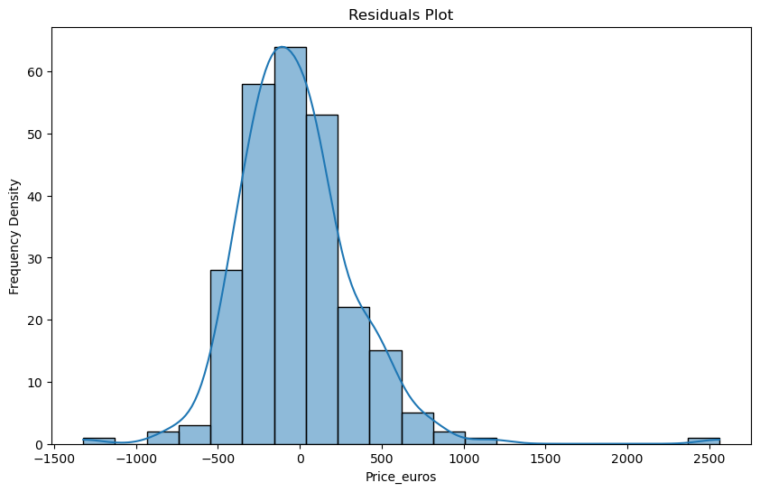

```python
plt.figure(figsize=(10, 6))
sns.histplot(residuals, kde=True,bins=20)
plt.ylabel('Frequency Density')
plt.title('Residuals Plot')
plt.show()
```

```python
from scipy.stats import shapiro

# Perform Shapiro-Wilk test for normality of residuals
residuals = y_test-y_pred
w_stat, p_value = shapiro(residuals)
print(f"Shapiro-Wilk statistic: {w_stat:.4f}")
print(f"p-value: {p_value:.15f}")


if p_value < 0.05:
    print("Reject the null hypothesis. The residuals are not normally distributed.")
else:
    print("Fail to reject the null hypothesis. The residuals are normally distributed.")
```

```
Shapiro-Wilk statistic: 0.9006
p-value: 0.000000000006189
Reject the null hypothesis. The residuals are not normally distributed.
```

## Random Forest Regressor Model

```python
## Create Random Forest Regressor Model
rf_model=RandomForestRegressor(n_estimators=100,random_state=42)

## Train the Model
rf_model.fit(X_train_scaled, y_train)
```

```
RandomForestRegressor(random_state=42)
```

```python
## Make Prediction on the test Dataset
Prediction=rf_model.predict(X_test_scaled)
```

```python
## Evaluate the Model Performance
mae = mean_absolute_error(y_test, Prediction)
mse = mean_squared_error(y_test, Prediction)
rmse = np.sqrt(mse)
r2 = r2_score(y_test, Prediction)
print(f"Mean Absolute Error :{mae:.2f}")
print(f"Root Mean Squared Error: {rmse:.2f}")
print(f"R-squared: {r2:.2f}")
```

```
Mean Absolute Error :161.39
Root Mean Squared Error: 251.75
R-squared: 0.87
```

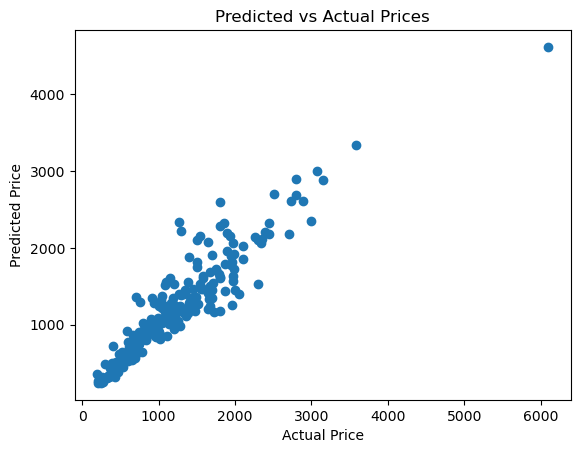

```python
## Plot the Predicted vs Actual prices
plt.scatter(y_test, Prediction)
plt.xlabel("Actual Price")
plt.ylabel("Predicted Price")
plt.title("Predicted vs Actual Prices")
plt.show()
```

## XGboost Algotithm

```python
pip install xgboost
```

```python
## Import Necessary Library
import xgboost as xgb
```

```python
## Create an XGBoost Regressor Model
model = xgb.XGBRegressor(objective='reg:squarederror', max_depth=5, learning_rate=0.1, n_estimators=1000, n_jobs=-1, random_state=42)
```

```python
## Train the Model
model.fit(X_train_scaled, y_train)
```

```
XGBRegressor(base_score=None, booster=None, callbacks=None,
             colsample_bylevel=None, colsample_bynode=None,
             colsample_bytree=None, device=None, early_stopping_rounds=None,
             enable_categorical=False, eval_metric=None, feature_types=None,
             gamma=None, grow_policy=None, importance_type=None,
             interaction_constraints=None, learning_rate=0.1, max_bin=None,
             max_cat_threshold=None, max_cat_to_onehot=None,
             max_delta_step=None, max_depth=5, max_leaves=None,
             min_child_weight=None, missing=nan, monotone_constraints=None,
             multi_strategy=None, n_estimators=1000, n_jobs=-1,
             num_parallel_tree=None, random_state=42, ...)
```

```python
## Make predictions on the test dataset
y_prediction = model.predict(X_test_scaled)
```

```python
## Evaluate the Model Performance
mse = mean_squared_error(y_test, y_prediction)
rmse = np.sqrt(mse)
r2 = r2_score(y_test, y_prediction)
print(f"Root Mean Squared Error: {rmse:.2f}")
print(f"R-squared: {r2:.2f}")
```

```
Root Mean Squared Error: 207.79
R-squared: 0.91
```

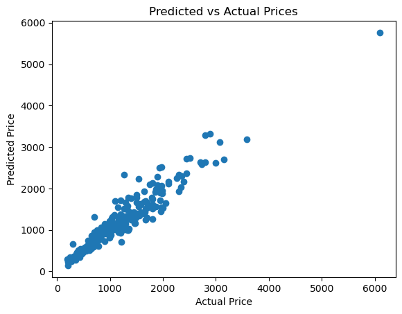

```python
## Plot the Predicted vs Actual Prices
plt.scatter(y_test, y_prediction)
plt.xlabel("Actual Price")
plt.ylabel("Predicted Price")
plt.title("Predicted vs Actual Prices")
plt.show()
```